# XGBoost Tutorial

Stat 253

Lilabeth Sokolewicz, Rishika Kundu, Shelly Bai

# Define and Discuss

## What is Boosting?

The boosting algorithm is a generalized approach used for improving the predictions from a decision tree. Boosting can be applied to both regression and classification settings. For the context of our project, we limit our discussion of boosting to classification using decision trees. The boosting algorithm grows several distinct trees sequentially, where each tree is grown using information from previously grown trees.

The boosting approach avoids overfitting by learning slowly. Given the current model, boosting fits a decision tree to the residuals from the model. It thus fits a tree using the current residuals, rather than the outcome Y, as the response. This new decision tree is added to the fitted function in order to update the residuals. This process is repeated until the residuals are minimized and the predictions from the tree can no longer be approved.

Extreme gradient boosting or XGBoost is a more regularized, scalable form of Gradient boosting. XGBoost utilizes its tuning parameters to be “better” at regularization strategies than gradient boosting. It is also faster and better scalability on large datasets compared to Gradient Boosting.

## XGBoost Algorithm:

Step 1: For a given binary response variable (y) with categories 0 and 1, make a uniform prediction (p) on a probability of class 1 for all the data points. This proportion of class 1 can be calculated using a mean of y.

Step 2: To improve our prediction quality, we focus on minimizing the residuals from our initial prediction. Build a regression tree model with outcome variables (x1 and x2) as its features and the residuals (r) as its target. This binary tree will predict two different residual values.

Step 3: Before adding these residual values to the initial prediction p, we need to calculate gamma (γ) for both residuals on the leaf node using the following formula:

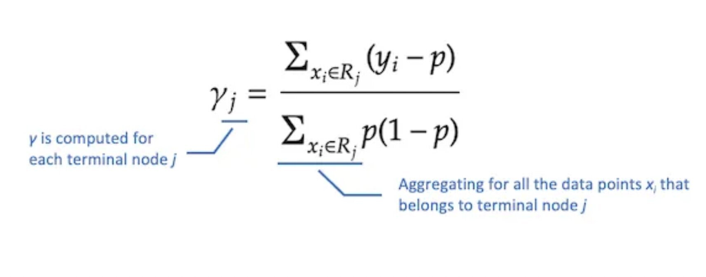

Image from the Medium, Mausi T, February 2022

Step 4: Convert initial probability to log odds.

Step 5: The new predictions (gamma) calculated in step 3 need to be scaled down by the learning rate ν, which ranges between 0 and 1. Scaling the predictions by the learning rate makes sure that the model is not overfit to the training data.

Step 6: After scaling the gamma values, add them to the initial prediction calculated in step 4. The following formula can be used as reference:

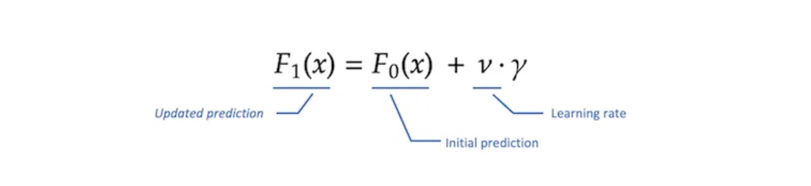

Image from the Medium, Mausi T, February 2022

Step 7: Convert the new updated prediction in log odds back to probability. This new probability prediction is an improvement from the original one calculated in step 1.

Step 8: Use the new probability threshold to identify new residuals. Repeat steps 1 to 7 to create residual trees on the new probability predictions. Continue iterating through these steps until the model prediction stops improving.

# Tuning Parameters and Bias-Variance Tradeoff:

Boosting generally has three main parameters: the number of trees, B, the shrinkage parameter, and the max depth d of each tree. A large number of trees can make the model overfit, since we are doing too much to make our model explain the noise in our sample data by fitting new trees on past ones’ residuals. Conversely, a small B will lead to high bias since there are too few trees to make accurate predictions or classifications. It is therefore best to select B by cross-validation while tuning the model. This parameter is called ‘trees’ in XGBoost, and is one of the parameters we use to tune our model.

The shrinkage parameter determines the rate at which the algorithm learns. A learning rate of less than 1 slows it down, and thus can prevent the model from becoming too variable. A small learning rate can require a large B to produce an effective model, since each tree is allowed to contribute less to the final prediction. We set the learning rate to a constant, .01, in our model.

The max depth d determines the complexity of the model: a large d increases the complexity of each tree in the model and can therefore make it highly variable; whereas a small d could give it higher bias. A high d is also very computationally expensive. d = 1 is often used in boosting, making it an additive model in which each new term involves only one variable–similar to a generalized additive model. However, in our model we use the default max_depth, which is 6.

XGBoost also considers gamma, or cost complexity. Increasing the value of gamma means that any potential split must reduce loss, or errors made by the model, by more in order for that split to be made. This process echoes the use of the Gini index in building trees. Higher gamma values make the XGBoost trees less variable, but may increase bias. Our model uses the default of 0, meaning that a split does not need to reduce loss in order to occur.

In addition to learning rate, we use ‘mtry’ and ‘min_n’ to tune our XGBoost model. mtry represents the number of predictors that are randomly sampled at each split of each tree, similar to random forests. Like in random forests, using more predictors makes each tree less biased, since we’re considering more possible splits. However, when each tree uses a similar subset of predictors, they are more similar to each other, which doesn’t decrease the variability of the model as a whole. Smaller values of mtry decrease variance in our overall model by making trees less similar to each other. min_n represents the minimum number of data points in a node required for another split to occur, much like in trees. Similar to the trees algorithm, a larger min_n produces a less variable and potentially more biased model, since trees are more pruned and aren’t allowed to get as specific to the data.

# Advantages and Disadvantages of Boosting (relative to trees, bagging, and forests)

## Comparison:

Bagging and Forests train decision trees in *parallel*: As ensemble classification methods, they train many trees at once, where the final prediction is the majority vote outcome.

However, boosting algorithms train trees *sequentially*: each subsequent model is trained to improve upon its predecessor’s mistakes (residuals), such that the final model’s prediction is a sum of outputs from all of the trees. In this way, the way the final model is put together is similar to how Generalized Additive Models (GAM) are built in a regression task.

## Pros of XGBoosting:

- Overfitting: Random forests and bagging have high accuracy, but they can become overfit to the data if the majority of trees in the forest have similar samples, since the trees are built unpruned. Bagging methods control for overfitting by building many trees with random variable selection, while XGBoost controls for overfitting by pruning trees. Similar to how regular classification trees are pruned, XGBoost prunes when the Gain in the similarity score between a node and its child is considered minimal (this is one of our regularization methods). XGBoosting results in generally smaller, more pruned trees compared to bagging methods.
- Because XGBoost adjusts its parameters iteratively, it is more flexible than bagging, forests, or trees when the data is highly varied, or in applications where new data is coming in real time. These parameters are adjusted at each successive tree using the loss function of the preceding tree.
- XGBoosting performs better than bagging, forests, or decision trees when our data has data imbalance, i.e. some classes are underrepresented in the data. Since XGBoost prioritizes improving upon the model’s misclassifications, subsequent trees will give more weightage to misclassified categories (usually the less-represented classes) and help to equalize the model’s prediction accuracy for all classes. In some cases, XGBoosting algorithm can “learn” to handle missing data [through minimizing the loss function](https://datascience.stackexchange.com/questions/15305/how-does-xgboost-learn-what-are-the-inputs-for-missing-values), reducing some need for preprocessing steps, and making XGBoosting potentially useful in cases where we have sparse or incomplete data.

## Cons of XGBoosting:

- XGBoosting is more complicated to work with and harder to tune than Random forests and bagging methods. Usually, we will tune multiple parameters at once and use grid search or randomized search methods to find the optimal settings.
- Because of the complexity of tuning, XGBoosting can become computationally expensive, scaling with deeper trees and larger datasets.
- XGBoosting has much less interpretability compared to single classification trees, as it is optimized for performance and accuracy of predictions.
- XGBoosting runs the risk of overfitting if the training set is small, given that it gives more weightage to misclassifications. In smaller datasets, misclassifications have a higher likelihood to simply be outliers, so an XGBoost model may overfit to outliers and noise in the data.

# Implementation of XGBoost

```r
land <- read.csv("https://bcheggeseth.github.io/253_spring_2024/data/land_cover.csv") %>%
  rename(type = class) %>%
  mutate(type = as.factor(type))

land_split <- land %>%
  initial_split(strata = type)
land_train <- training(land_split)
land_test <- testing(land_split)

set.seed(234)
land_folds <- vfold_cv(land_train, strata = type)

land_rec <-
  recipe(type ~ Mean_G + NDVI + Bright_100 + SD_NIR,
  data = land_train
  ) %>%
  step_unknown(all_nominal_predictors()) %>%
  step_dummy(all_nominal_predictors(), one_hot = TRUE) %>%
  step_nzv(all_predictors())

xgb_spec <-
  boost_tree(
    trees = tune(),
    min_n = tune(),
    mtry = tune(),
    learn_rate = 0.01
  ) %>%
  set_engine("xgboost") %>%
  set_mode("classification")

xgb_wf <- workflow(land_rec, xgb_spec)

doParallel::registerDoParallel()

set.seed(345)
xgb_rs <- tune_race_anova(
  xgb_wf,
  resamples = land_folds,
  grid = 15,
  metrics = metric_set(mn_log_loss),
  control = control_race(verbose_elim = TRUE)
)

xgb_last <- xgb_wf %>%
  finalize_workflow(select_best(xgb_rs, metric = "mn_log_loss")) %>%
  last_fit(land_split)

xgb_last
```

```
## # Resampling results
## # Manual resampling
## # A tibble: 1 × 6
##   splits            id               .metrics .notes   .predictions .workflow
##   <list>            <chr>            <list>   <list>   <list>       <list>
## 1 <split [505/170]> train/test split <tibble> <tibble> <tibble>     <workflow>
```

```r
collect_predictions(xgb_last) %>%
  mn_log_loss(type, 2:10)
```

```
## # A tibble: 1 × 3
##   .metric     .estimator .estimate
##   <chr>       <chr>          <dbl>
## 1 mn_log_loss multiclass     0.485
```

## Random Forest Comparison

```r
set.seed(253)
rf_spec <- rand_forest()  %>%
  set_mode("classification") %>%
  set_engine(engine = "ranger") %>%
  set_args(
    mtry = NULL,
    trees = 500,
    min_n = 2,
    probability = FALSE,
    # give classifications, not probability calculations
    importance = "impurity",
    # use Gini index to measure variable importance
    metrics = metric_set(mn_log_loss)
  )

land_forest <- rf_spec %>%
  fit(type ~ Mean_G + NDVI + Bright_100 + SD_NIR, data = land_train)

land_forest %>%
  extract_fit_engine() %>%
  pluck("confusion.matrix") %>%
  t()
```

```
##            true
## predicted   asphalt  building  car  concrete  grass  pool  shadow  soil  tree
##   asphalt         46         2    0         0      0     0       6     0     0
##   building         1        61    5        14      0     1       0     2     0
##   car              1         2   19         2      0     0       1     0     0
##   concrete         0        17    1        61      0     0       0     2     1
##   grass            0         0    0         0     77     0       0     3     5
##   pool             0         0    0         0      0    21       0     0     0
##   shadow           4         0    0         0      0     1      37     0     1
##   soil             0         6    2         4      1     0       0    22     0
##   tree             0         0    0         0      4     0       0     0    72
```

```r
land_forest %>%
  extract_fit_engine() %>%
  pluck("variable.importance") %>%
  sort(decreasing = TRUE)
```

```
##       NDVI Bright_100     Mean_G     SD_NIR
##  154.03918  109.49408   94.23504   75.08149
```

```r
land_forest %>%
  predict(new_data = land_train) %>%
  cbind(land_train) %>%
  conf_mat(truth = type,
           estimate = .pred_class)
```

```
##            Truth
## Prediction  asphalt  building  car  concrete  grass  pool  shadow  soil  tree
##   asphalt         52         0    0         0      0     0       0     0     0
##   building         0        88    0         0      0     0       0     0     0
##   car              0         0   27         0      0     0       0     0     0
##   concrete         0         0    0        81      0     0       0     0     0
##   grass            0         0    0         0     82     0       0     0     0
##   pool             0         0    0         0      0    23       0     0     0
##   shadow           0         0    0         0      0     0      44     0     0
##   soil             0         0    0         0      0     0       0    29     0
##   tree             0         0    0         0      0     0       0     0    79
```

```r
land_forest
```

```
## parsnip model object
##
## Ranger result
##
## Call:
##  ranger::ranger(x = maybe_data_frame(x), y = y, num.trees = ~500,      min.node.size = min_rows(~2, x), probability = ~FALSE, importance = ~"impurity",      metrics = ~metric_set(mn_log_loss), num.threads = 1, verbose = FALSE,      seed = sample.int(10^5, 1))
##
## Type:                             Classification
## Number of trees:                  500
## Sample size:                      505
## Number of independent variables:  4
## Mtry:                             2
## Target node size:                 2
## Variable importance mode:         impurity
## Splitrule:                        gini
## OOB prediction error:             17.62 %
```

# Model Evaluation

## Is the model good?

This model is non parametric and does not assume a linear relationship between the variables. This allows for greater flexibility in variable relationships. The model algorithm also focuses on improving misclassifications, and thus it can improve accuracy for low-frequency classes.

However, XGBoosting is comparatively more complicated to implement and optimize. The model has low interpretability, especially when compared to a classification tree which would be a lot easier to interpret. The model can also be sensitive to outliers and overfitting. In this case, since misclassifications account for a lower frequency class in our data and we are working with a small dataset, the XGBoost algorithm is not ideal for this task.

## Is the model fair?

The land dataset used for the implementation of the model raises questions about data collection strategies. Using aerial photography to classify different types of land can be considered as surveillance. Furthermore, classification of natural resources can be used for exploitative purposes leading to environmental destruction or hindering a communities access to natural resources. Misclassifications can also lead to harm by environmental implementing policies on unsuitable types of land.

# Contributions

We each took the lead on one part of the Define and Discuss part: Rishika wrote the ‘What is Boosting?’ and ‘XGBoost’ sections; Lilabeth the ‘Tuning Parameters and Bias-Variance Tradeoff’ section; and Shelly the ‘Advantages and Disadvantages’ section. We all worked through understanding and implementing the code together. We also evaluated the model together and collectively wrote our final evaluation.

# References:

Masui, T. (2022, February 7). All You Need to Know about Gradient Boosting Algorithm − Part 2. Classification. Medium. Retrieved April 11, 2024, from https://towardsdatascience.com/all-you-need-to-know-about-gradient-boosting-algorithm-part-2-classification-d3ed8f56541e

An Introduction to Statistical Learning with Applications in R, Section 8.2.3